## Preface

This demo blog post uses a very developmental version of `fmi`. To run the demo on your own computer, you will have to do the following:

```r
# fmi depends on rwfs
install_github("ropengov/rwfs")
install_github("ropengov/fmi")
```

## Accessing FMI weather station data using package fmi

As explained in the [previous post](https://ropengov.github.io/general/2014/09/30/fmi/), package [`fmi`](https://github.com/rOpenGov/fmi) brings various kinds of data from the Finnish Meteorological Institute’s (FMI) open API to R. The work on the package is still very much in progress, but when I got asked if it’s possible to get location (i.e. wheather station) specific precipitation and temperature data for a specific time period, I decided to take `fmi` for a spin.

FMI deserves compliments for the implemenetation of an open API, but the documentation of some of the API parameters has left room for improvement. For some lively discussion (in Finnish), see [here](https://www.facebook.com/groups/fi.okfn/permalink/10152804124115628/). Fortunately, method [getDailyWeather()](https://github.com/rOpenGov/fmi/blob/master/vignettes/fmi_tutorial.md#automated-request) in `fmi` returns the necessary measurements (precipitation and temperature) as is, so no need to figure out the specific parameter values for the request. A [little more digging](http://data.fmi.fi/fmi-apikey/cdc84a28-60b7-44c3-ad5d-442d34edc435/meta?observableProperty=observation&param=rrday,tday,snow,tmin,tmax&language=eng) does reveal, however, more information for example on the units used to record the measurements. Hand picking the information from the XML reveals the following table:

| Parameter | Label | Base phenomenon | Unit | Stat function | Agg time period |
| --- | --- | --- | --- | --- | --- |
| rrday | Precipitation amount | Amount of precipitation | mm | acc | PT24H |
| snow | Snow depth | Snow cover | cm | instant | PT1M |
| tday | Air temperature | Temperature | degC | avg | P1D |
| tmax | Maximum temperature | Temperature | degC | max | PT24H |
| tmin | Minimum temperature | Temperature | degC | min | PT24H |

So far so good, `rrday` and `tday` should do the trick. However, we still need to be able to query a specific weather station, for which we need some sort of an identifier. The location we’re interested is Kiutaköngäs in Kuusamo, a rather spectacular section of rapids in the river Oulanka located right next to the [Oulanka national park](https://en.wikipedia.org/wiki/Oulanka_National_Park):

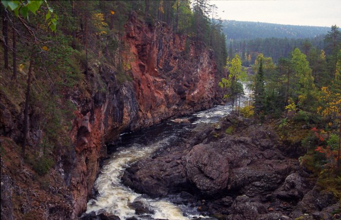

Kiutaköngäs

It turns out (not by coincidence) that FMI has an active observation station located at Kiutaköngäs. It may be possible to get a full list of weather stations throught the FMI API itself, but so far `fmi` does not know anything about it. In the meanwhile, I scraped [a table of observation stations](http://en.ilmatieteenlaitos.fi/observation-stations) from the FMI web site, and created a utility function `fmi_weather_stations()` in `fmi`. The function returns a dataframe of all active observation stations:

```
##                               Nimi FMISID LPNN   WMO    Lat    Lon Korkeus    Ryhmät Alkaen
## 1                   Alajärvi Möksy 101533 3314  2787  63,09  24,26     170 Sääasemat   1996
## 2                   Antarktis Aboa 112275 9950 89014 -73,05 -13,38     497 Sääasemat   2003
## 3          Asikkala Pulkkilanharju 101185 1434  2727  61,27  25,52      80 Sääasemat   1991
## 4 Enontekiö Kilpisjärvi kyläkeskus 102016 9003  2801  69,05  20,79     480 Sääasemat   1983
## 5      Enontekiö Kilpisjärvi Saana 102017 9004  2701  69,04  20,85    1002 Sääasemat   1991
## 6             Enontekiö lentoasema 101976 8208  2802  68,36  23,43     306 Sääasemat   1999
```

Using column `FMISID` seems promising, and with a little skimming through the table, we can locate the correct station:

```r
kiutakongas.station <- stations[99,]
kiutakongas.station
```

```
##                   Nimi FMISID LPNN  WMO   Lat   Lon Korkeus    Ryhmät Alkaen
## 99 Kuusamo Kiutaköngäs 101887 6802 2811 66,37 29,31     165 Sääasemat   1966
```

The convience methods in `fmi` took a little adjusting, but afterwards it is possible to use `FMISID` in the query paramaters. Following the `fmi` tutorial, it is now possible to do the following. **NOTE!** You will need to provide [your own apiKey](http://en.ilmatieteenlaitos.fi/open-data-manual-fmi-wfs-services) first:

```r
apiKey <- "ENTER YOUR API KEY HERE"
```

```r
# Set the correct FMISID
fmisid.kiuta <- kiutakongas.station$FMISID

request <- FMIWFSRequest$new(apiKey=apiKey)

request$setParameters(request="getFeature",
                      storedquery_id="fmi::observations::weather::daily::timevaluepair",
                      parameters="rrday,snow,tday,tmin,tmax")

client <- FMIWFSClient$new(request=request)

response <- client$getDailyWeather(startDateTime="2014-01-01T00:00:00Z",
                                   endDateTime="2014-01-01T00:00:00Z",
                                   fmisid=fmisid.kiuta)
```

Obviously we are usually interested in time periods longer than one day. In addition, massaging the data returned by `getDailyWeather()` still takes a little manual work. Wrapping this manual work into an utility function:

```r
# dplyr FTW!
library(dplyr)

get_weather_data <- function(apiKey, startDateTime, endDateTime, fmisid) {

  request <- FMIWFSRequest$new(apiKey=apiKey)

  request$setParameters(request="getFeature",
                        storedquery_id="fmi::observations::weather::daily::timevaluepair",
                        parameters="rrday,snow,tday,tmin,tmax")

  client <- FMIWFSClient$new(request=request)
  response <- client$getDailyWeather(startDateTime=startDateTime,
                                     endDateTime=endDateTime,
                                     fmisid=fmisid)
  dat <- as.data.frame(response)

  # Manual splicing and dicing
  # 1. Get just the time, variable, and measurement
  # 2. Replace NaNs in the response with NAs and convert measurement to numeric
  # 3. Coerce time strings to Dates
  measurements <- dat %>%
    select(time, variable, measurement) %>%
    mutate(measurement=as.numeric(ifelse(is.na(measurement), NA, measurement))) %>%
    mutate(time=as.Date(time))

  return(measurements)
}
```

Using the function above simplifies querying. For demonstration, let’s get data for the whole year 2012:

```r
startDateTime <- "2012-01-01"
endDateTime <- "2012-12-31"

kiuta.2012 <- get_weather_data(apiKey, startDateTime, endDateTime, fmisid.kiuta)
```

Let’s take a look at the measurement data (first 2 days):

```r
head(kiuta.2012, 10)
```

```
##          time variable measurement
## 1  2012-01-01    rrday        -1.0
## 2  2012-01-01     snow        50.0
## 3  2012-01-01     tday        -6.0
## 4  2012-01-01     tmin        -9.8
## 5  2012-01-01     tmax        -3.6
## 6  2012-01-02    rrday         0.5
## 7  2012-01-02     snow        47.0
## 8  2012-01-02     tday        -7.9
## 9  2012-01-02     tmin        -9.8
## 10 2012-01-02     tmax        -6.7
```

The measurements may contain NAs and values -1, which I suspect may also have something to do with missing values but can’t say for sure.

For comparison’s sake, let’s also get some data from Kaisaniemi (Helsinki) observation station:

```r
fmisid.kaisa <- stations[24,]$FMISID

kaisa.2012 <- get_weather_data(apiKey, startDateTime, endDateTime, fmisid.kaisa)
```

### Plotting

Let’s inspect the data by some plotting. First, however, some more data processing:

```r
kiuta.2012$location <- "Kuusamo, Kiutaköngäs"

kaisa.2012$location <- "Helsinki, Kaisaniemi"

dat <- rbind(kiuta.2012, kaisa.2012)
```

First, let’s plot the minimum (`tmin`), the average (`tday`) and the maximum (`tmax`) temperature per day over year 2012. Plotting below uses a custom theme for `ggplot2`.

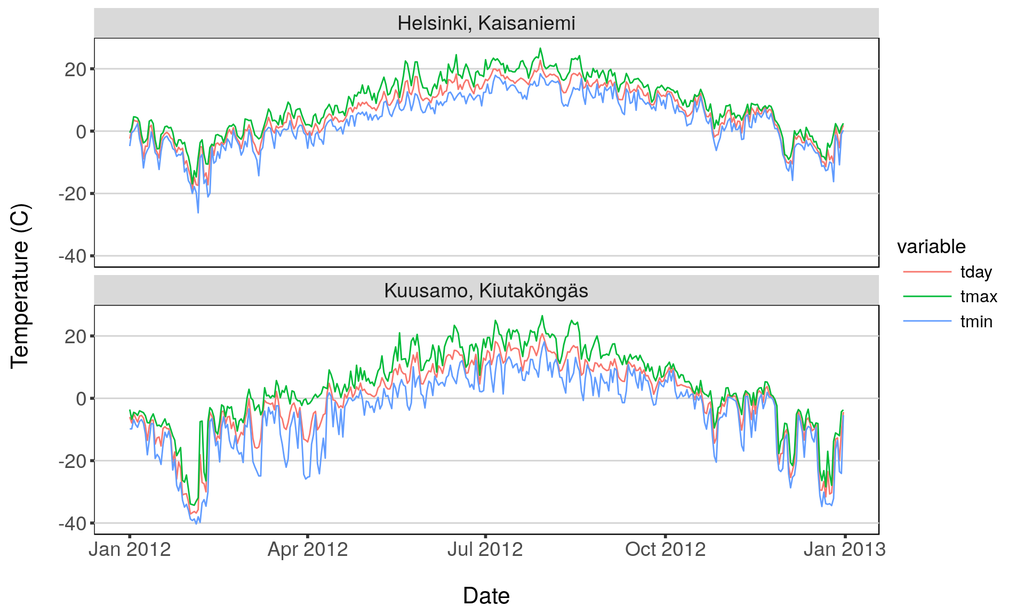

```r
library(ggplot2)

p <- ggplot(dplyr::filter(dat, variable %in% c("tday", "tmax", "tmin")), aes(x=time, y=measurement, color=variable))
p + geom_line() + facet_wrap(~ location, ncol=1) + ylab("Temperature (C)\n") +
  xlab("\nDate") + custom.theme
```

While we’re at it, let’s also plot the snowdepth:

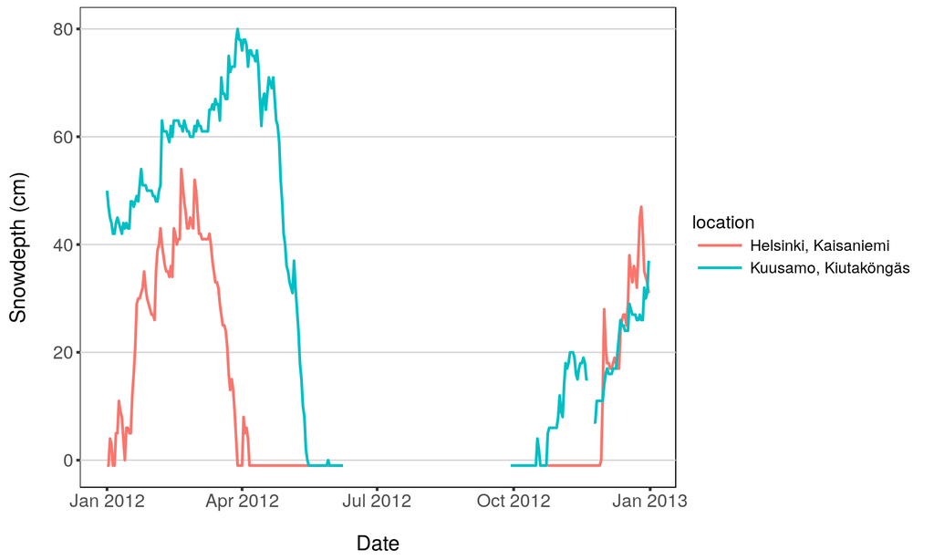

```r
p <- ggplot(dplyr::filter(dat, variable == "snow"), aes(x=time, y=measurement, color=location))
p + geom_line(size=1) + xlab("\nDate") + ylab("Snowdepth (cm)\n") + custom.theme
```

Finally, let’s take a look at precipitation measurement values and their means:

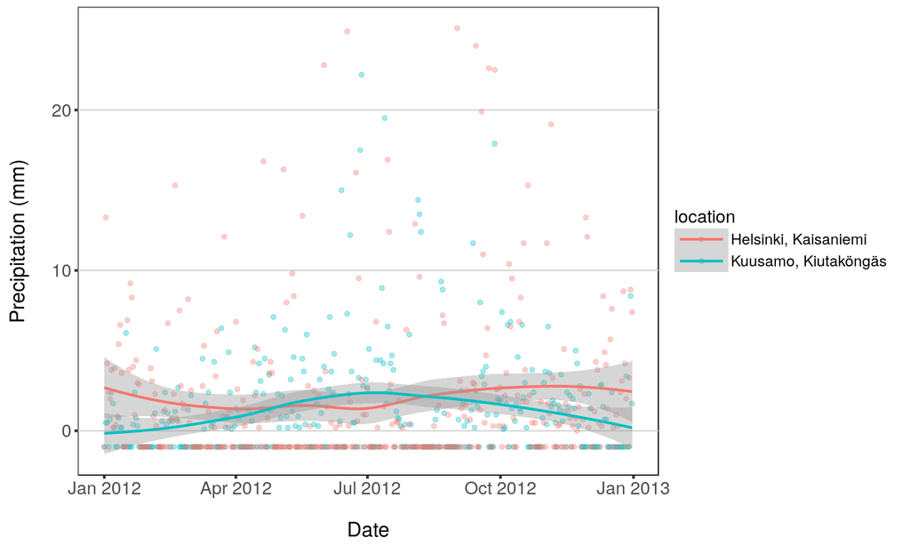

```r
p <- ggplot(dplyr::filter(dat, variable == "rrday"), aes(x=time, y=measurement, color=location))
p + geom_point(alpha=1/3) + stat_smooth(method="loess", size=1) + xlab("\nDate") +
  ylab("Precipitation (mm)\n") + custom.theme
```

That’s it, a small demo on how to use `fmi` package for fetching observation station specific data.